# Descripción del proyecto

El servicio de venta de autos usados Rusty Bargain está desarrollando una aplicación para atraer nuevos clientes. Gracias a esa app, puedes averiguar rápidamente el valor de mercado de tu coche. Tenemos acceso al historial: especificaciones técnicas, versiones de equipamiento y precios. Debemos crear un modelo que determine el valor de mercado.

A Rusty Bargain le interesa:

- la calidad de la predicción;
- la velocidad de la predicción;
- el tiempo requerido para el entrenamiento

# Tabla de contenidos

## Inicialización

```python
# Cargamos todas las librerías a usar
import pandas as pd
from IPython.display import display, HTML, Image
import matplotlib.pyplot as plt
import numpy as np
import time


from sklearn.model_selection import train_test_split
from sklearn.metrics import mean_squared_error

from sklearn.tree import DecisionTreeRegressor
from sklearn.ensemble import RandomForestRegressor
from sklearn.linear_model import LinearRegression

from sklearn.model_selection import GridSearchCV

from catboost import CatBoostRegressor
import lightgbm as lgb
import xgboost as xgb


#Para que las tablas no tengan limite al momento de mostrarse
pd.set_option('display.max_rows', None)
pd.set_option('display.max_columns', None)
```

```python
#Definimos una función Print que sea visualmente mas amigable
def print_mejorado(texto,size):
    size=str(size)
    display(HTML('<span style="font-size: '+size+'px;">'+texto+'</span>'))
```

## Preparación de datos

### Carga de datos

```python
# Carga de los datos
data=pd.read_csv('/datasets/car_data.csv')
```

### Analisis de tipo de datos

```python
data.info()
```

```
<class 'pandas.core.frame.DataFrame'>
RangeIndex: 354369 entries, 0 to 354368
Data columns (total 16 columns):
 #   Column             Non-Null Count   Dtype
---  ------             --------------   -----
 0   DateCrawled        354369 non-null  object
 1   Price              354369 non-null  int64
 2   VehicleType        316879 non-null  object
 3   RegistrationYear   354369 non-null  int64
 4   Gearbox            334536 non-null  object
 5   Power              354369 non-null  int64
 6   Model              334664 non-null  object
 7   Mileage            354369 non-null  int64
 8   RegistrationMonth  354369 non-null  int64
 9   FuelType           321474 non-null  object
 10  Brand              354369 non-null  object
 11  NotRepaired        283215 non-null  object
 12  DateCreated        354369 non-null  object
 13  NumberOfPictures   354369 non-null  int64
 14  PostalCode         354369 non-null  int64
 15  LastSeen           354369 non-null  object
dtypes: int64(7), object(9)
memory usage: 43.3+ MB
```

```python
data.head()
```

|  | DateCrawled | Price | VehicleType | RegistrationYear | Gearbox | Power | Model | Mileage | RegistrationMonth | FuelType | Brand | NotRepaired | DateCreated | NumberOfPictures | PostalCode | LastSeen |
| --- | --- | --- | --- | --- | --- | --- | --- | --- | --- | --- | --- | --- | --- | --- | --- | --- |
| 0 | 24/03/2016 11:52 | 480 | NaN | 1993 | manual | 0 | golf | 150000 | 0 | petrol | volkswagen | NaN | 24/03/2016 00:00 | 0 | 70435 | 07/04/2016 03:16 |
| 1 | 24/03/2016 10:58 | 18300 | coupe | 2011 | manual | 190 | NaN | 125000 | 5 | gasoline | audi | yes | 24/03/2016 00:00 | 0 | 66954 | 07/04/2016 01:46 |
| 2 | 14/03/2016 12:52 | 9800 | suv | 2004 | auto | 163 | grand | 125000 | 8 | gasoline | jeep | NaN | 14/03/2016 00:00 | 0 | 90480 | 05/04/2016 12:47 |
| 3 | 17/03/2016 16:54 | 1500 | small | 2001 | manual | 75 | golf | 150000 | 6 | petrol | volkswagen | no | 17/03/2016 00:00 | 0 | 91074 | 17/03/2016 17:40 |
| 4 | 31/03/2016 17:25 | 3600 | small | 2008 | manual | 69 | fabia | 90000 | 7 | gasoline | skoda | no | 31/03/2016 00:00 | 0 | 60437 | 06/04/2016 10:17 |

```python
#Renombramos las columnas a tipo snake_case
data = data.rename(columns={
    'DateCrawled': 'date_crawled',
    'Price': 'price',
    'VehicleType': 'vehicle_type',
    'RegistrationYear': 'registration_year',
    'Gearbox': 'gearbox',
    'Power': 'power',
    'Model': 'model',
    'Mileage': 'mileage',
    'RegistrationMonth': 'registration_month',
    'FuelType': 'fuel_type',
    'Brand': 'brand',
    'NotRepaired': 'not_repaired',
    'DateCreated': 'date_created',
    'NumberOfPictures': 'number_of_pictures',
    'PostalCode': 'postal_code',
    'LastSeen': 'last_seen'
})
```

```python
#Transformamos los valores de fecha de tipo object a datetime
data['date_crawled'] = pd.to_datetime(data['date_crawled'], format='%d/%m/%Y %H:%M')
data['date_created'] = pd.to_datetime(data['date_created'], format='%d/%m/%Y %H:%M')
data['last_seen'] = pd.to_datetime(data['last_seen'], format='%d/%m/%Y %H:%M')
data.info()
```

```
<class 'pandas.core.frame.DataFrame'>
RangeIndex: 354369 entries, 0 to 354368
Data columns (total 16 columns):
 #   Column              Non-Null Count   Dtype
---  ------              --------------   -----
 0   date_crawled        354369 non-null  datetime64[ns]
 1   price               354369 non-null  int64
 2   vehicle_type        316879 non-null  object
 3   registration_year   354369 non-null  int64
 4   gearbox             334536 non-null  object
 5   power               354369 non-null  int64
 6   model               334664 non-null  object
 7   mileage             354369 non-null  int64
 8   registration_month  354369 non-null  int64
 9   fuel_type           321474 non-null  object
 10  brand               354369 non-null  object
 11  not_repaired        283215 non-null  object
 12  date_created        354369 non-null  datetime64[ns]
 13  number_of_pictures  354369 non-null  int64
 14  postal_code         354369 non-null  int64
 15  last_seen           354369 non-null  datetime64[ns]
dtypes: datetime64[ns](3), int64(7), object(6)
memory usage: 43.3+ MB
```

### Analisis y acondicionamiento de datos

```python
#Creamos funcion para visualizar rapidamente histogramas y datos descriptivos de cada columnas numericas
def histo_des(df):
    fig, (ax1, ax2) = plt.subplots(nrows=1, ncols=2, figsize=(20, 8))
    df.hist(ax=ax1,bins=20, figsize=(20,5))
    ax1.set_xlabel('Valores')
    ax1.set_ylabel('Frecuencia')
    ax1.set_title(df.name)

    ax2.axis('off')
    ax2.text(0, 0.5, str(df.describe()), fontsize=20, va='center')
    plt.subplots_adjust(wspace=0.5)
    plt.show()

    print_mejorado(f"Datos ausentes: {df.isnull().sum()}",24)
```

#### Columna `date_crawled`

```python
data['date_crawled'].describe(datetime_is_numeric=True)
```

```
count                           354369
mean     2016-03-21 12:57:41.165057280
min                2016-03-05 14:06:00
25%                2016-03-13 11:52:00
50%                2016-03-21 17:50:00
75%                2016-03-29 14:37:00
max                2016-04-07 14:36:00
Name: date_crawled, dtype: object
```

Las fechas es encuentran dentro de valores esperados.

#### Columna `price`

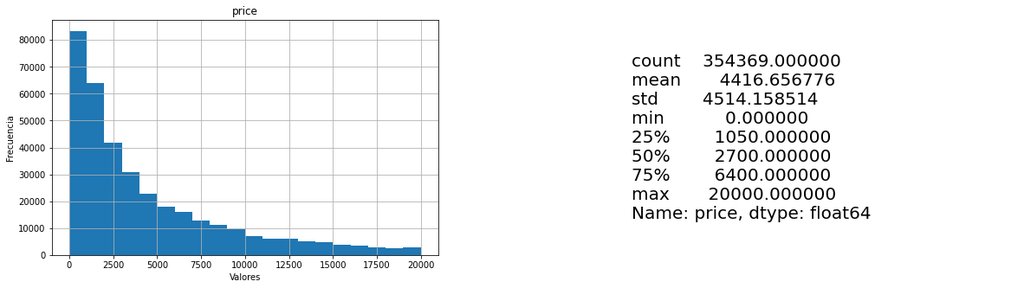

Datos ausentes: 0

```python
histo_des(data['price'])
```

Los precios se encuentran dentro de valores esperados.

#### Columna `vehicle_type`

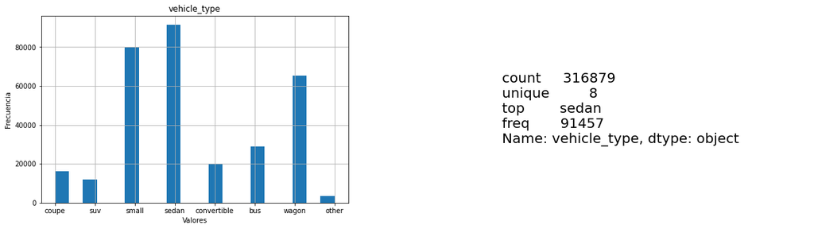

Datos ausentes: 37490

```python
histo_des(data['vehicle_type'])
```

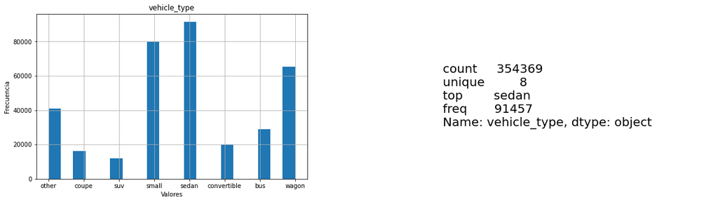

Datos ausentes: 0

```python
data['vehicle_type'] = data['vehicle_type'].fillna('other')
#Transformamos a variable categorica
data['vehicle_type'] = data['vehicle_type'].astype('category')
#Revisamos que el cambio se haya efectuado
histo_des(data['vehicle_type'])
```

#### Columna `registration_year`

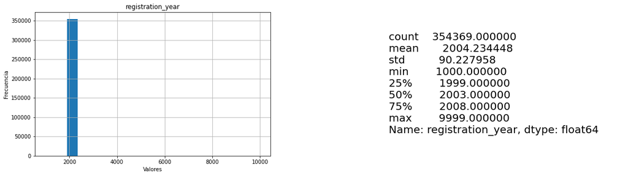

Datos ausentes: 0

```python
histo_des(data['registration_year'])
```

```python
#Miramos los años unicos y su cantidad de apariciones
data['registration_year'].value_counts().sort_index()
```

```
1000       37
1001        1
1039        1
1111        3
1200        1
1234        4
1253        1
1255        1
1300        2
1400        1
1500        5
1600        2
1602        1
1688        1
1800        5
```

[output cut: 137 more lines]

Vemos varios valores atipicos correspondiente a años, como por ejemplo 9999, 8500, 2066, 1234, 1800, 1910 y si bien, algunos valores pueden ser años validos, por un tema de simplicidad, procederé a borrar los datos de años inferiores a 1950 y mayores a 2019.

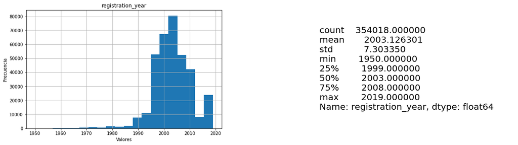

Datos ausentes: 0

```python
data = data.drop(data[data['registration_year'] > 2019].index)
data = data.drop(data[data['registration_year'] < 1950].index)
#Verificamos que los cambios se hayan aplicado correctamente
histo_des(data['registration_year'])
```

#### Columna `gearbox`

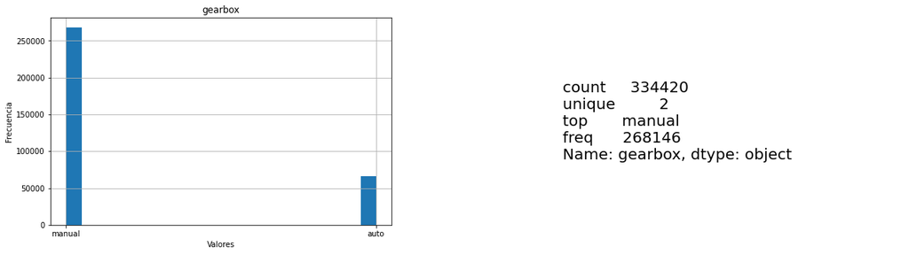

Datos ausentes: 19598

```python
histo_des(data['gearbox'])
```

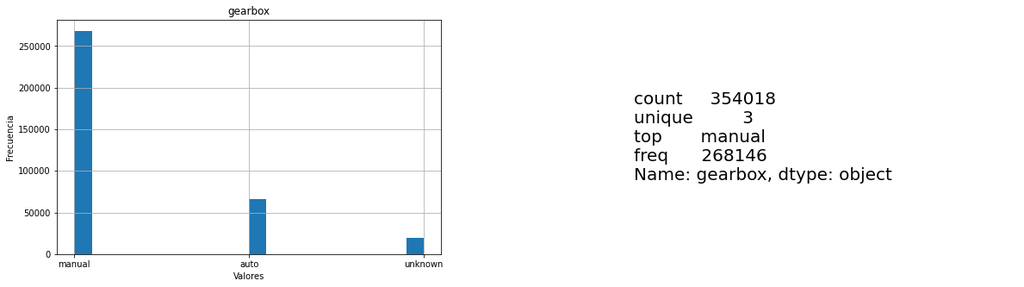

Datos ausentes: 0

```python
data['gearbox'] = data['gearbox'].fillna('unknown')
#Transformamos a variable categorica
data['gearbox'] = data['gearbox'].astype('category')
#Revisamos que el cambio se haya efectuado
histo_des(data['gearbox'])
```

#### Columna `power`

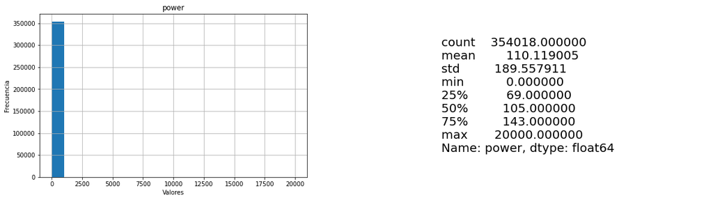

Datos ausentes: 0

```python
histo_des(data['power'])
```

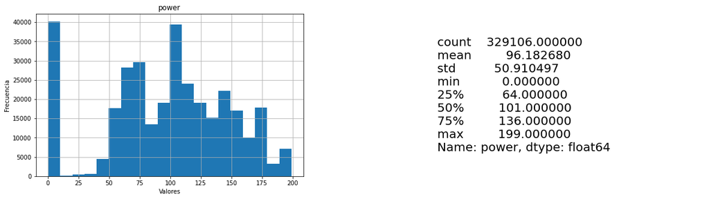

Datos ausentes: 0

```python
#Miramos mas de cerca para valores menores a 200
histo_des(data[data['power'] < 200]['power'])
```

Haciendo un sondeo rapido en internet, los CV normales en los autos son:

- Carros de uso urbano: Entre 80 y 100 HP.
- SUV compactos: 120 HP aproximadamente.
- SUV y camionetas: entre 170 y 200 HP.

Por lo que valores por sobre este rango muy probablemente corresponda a un error.  
Estudiaremos los valores atipicos usando el Rango intercuartílico (IQR)

```python
Q1 = data['power'].quantile(0.25)
Q2 = data['power'].quantile(0.5)
Q3 = data['power'].quantile(0.75)
IQR=(Q3-Q1)

print_mejorado(f"Limite superior de datos normales: {Q2+1.5*IQR}",20)
```

Limite superior de datos normales: 216.0

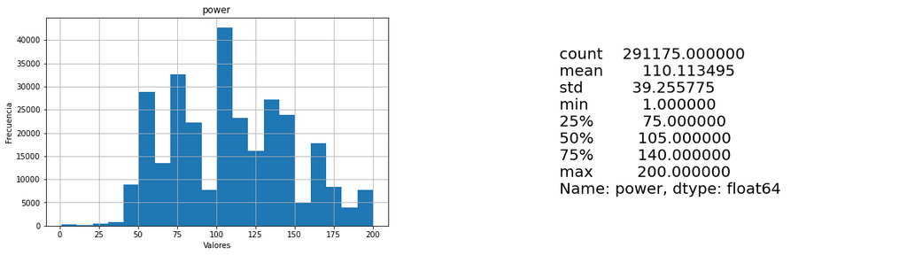

Datos ausentes: 0

```python
data = data.drop(data[data['power'] > 200].index)
data = data.drop(data[data['power'] == 0].index)
histo_des(data['power'])
```

#### Columna `model`

Al ser una **variable categorica** no númerica, revisamos los valores unicos.

```python
#Revisamos valores unicos
data['model'].unique()
```

```
array([nan, 'grand', 'golf', 'fabia', '3er', '2_reihe', 'other', 'c_max',
       '3_reihe', 'passat', 'navara', 'polo', 'twingo', 'a_klasse',
       'scirocco', 'meriva', 'arosa', '5er', 'c4', 'civic', 'transporter',
       'punto', 'e_klasse', 'clio', 'kadett', 'one', 'fortwo', '1er',
       'b_klasse', 'jetta', 'astra', 'fiesta', 'c_klasse', 'micra',
       'vito', 'sprinter', '156', 'escort', 'forester', 'xc_reihe',
       'scenic', 'ka', 'a1', 'focus', 'a4', 'a6', 'jazz', 'omega', 'slk',
       'combo', 'corsa', '80', '147', 'z_reihe', 'sportage', 'sorento',
       'ibiza', 'eos', 'touran', 'getz', 'insignia', 'almera', 'megane',
       'a3', 'lupo', 'r19', 'caddy', 'mondeo', 'cordoba', 'colt',
       'impreza', 'vectra', 'berlingo', '7er', 'tiguan', 'i_reihe', 'tt',
       '6_reihe', 'panda', 'up', 'ceed', 'kangoo', '5_reihe', 'yeti',
       'octavia', 'zafira', 'mii', 'rx_reihe', 'modus', 'fox', 'matiz',
       'beetle', 'rio', 'logan', 'spider', 'cuore', 's_max', 'a2',
       'galaxy', 'c3', 'viano', '1_reihe', 'sharan', 'avensis',
       'roomster', 'kaefer', 'santa', 'cooper', '4_reihe', 'laguna',
       'ptcruiser', 'clk', 'primera', 'espace', 's_klasse', 'exeo', '159',
       'transit', 'juke', 'v40', 'carisma', 'accord', 'corolla', 'lanos',
       'x_reihe', 'verso', 'swift', 'rav', 'qashqai', 'picanto', 'superb',
       'stilo', 'alhambra', 'mx_reihe', 'roadster', 'ypsilon', 'galant',
       'justy', 'leon', '90', 'sirion', 'signum', 'agila', 'duster',
       'v50', 'a8', '500', 'c_reihe', 'v_klasse', 'yaris', 'c5', 'aygo',
       'seicento', 'carnival', 'fusion', 'bora', 'forfour', 'a5', 'tigra',
       '100', 'cr_reihe', 'spark', 'kuga', 'm_klasse', 'x_type', 'ducato',
       'x_trail', 'toledo', 'altea', 'voyager', 'calibra', 'v70', 'bravo',
       'tucson', 'c1', 'citigo', 'jimny', 'wrangler', 'lybra', 'lancer',
       'captiva', 'sl', 'c2', 'discovery', 'freelander', 'sandero',
       'note', 'antara', '900', 'clubman', 'defender', '601', 'cx_reihe',
       'legacy', 'pajero', 'auris', 'cc', 'niva', 's60', 'nubira',
       'vivaro', 'g_klasse', 'cherokee', 'lodgy', 'range_rover', '850',
       'q3', 'mustang', 'serie_2', 'charade', 'croma', 'touareg', 'doblo',
       'musa', '6er', 'cl', '9000', 'kalos', 'v60', 'aveo', '200', '145',
       'outlander', 'b_max', 'range_rover_sport', 'move', 'glk',
       'm_reihe', 'rangerover', 'q5', 'materia', 'delta', 'terios',
       '300c', 's_type', 'kalina', 'elefantino', 'i3', 'samara', 'amarok',
       'kappa', '911', 'serie_3', 'crossfire', 'boxster', 'phaeton'],
      dtype=object)
```

Revisamos si existen valores nulos, y de haberlos, seran reemplazados con la etiqueta "other" y finalmente transformamos a una varirable categorica.

```python
#Evaluamos si hay datos nulos
print_mejorado(f"Datos Ausentes: {data['model'].isnull().sum()}",20)
#Reemplazamos por other
data['model'] = data['model'].fillna('other')
#Verificamos que ya no hay datos ausentes
print_mejorado(f"Datos Ausentes despues: {data['model'].isnull().sum()}",20)
#Transformamos a variable categorica
data['model'] = data['model'].astype('category')
```

Datos Ausentes: 12159

Datos Ausentes despues: 0

#### Columna `mileage`

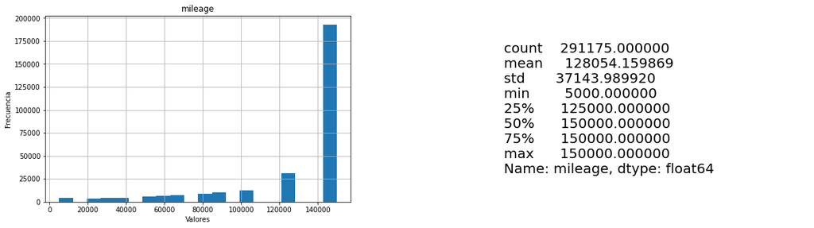

Datos ausentes: 0

```python
histo_des(data['mileage'])
```

Los valores se encuentran dentro de los esperado.

#### Columna `registration_month`

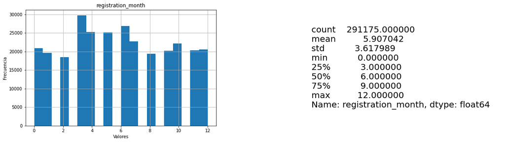

Datos ausentes: 0

```python
histo_des(data['registration_month'])
```

Los valores se encuentran dentro de los esperado (0-12).

#### Columna `fuel_type`

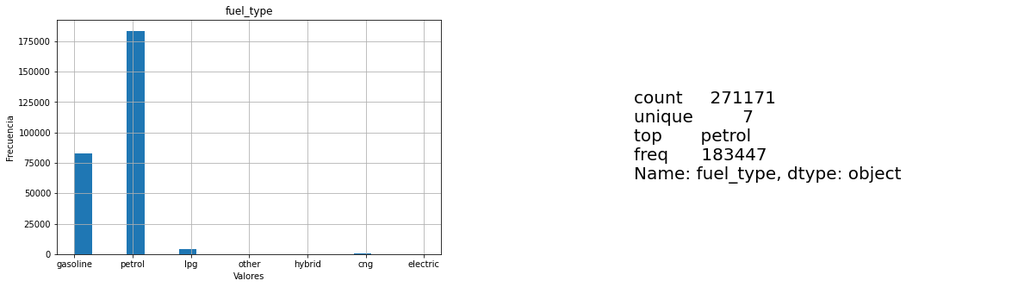

Datos ausentes: 20004

```python
histo_des(data['fuel_type'])
```

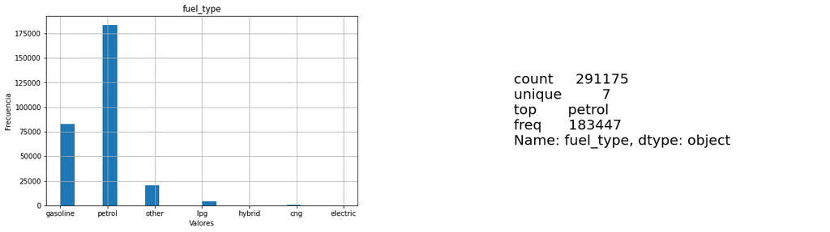

Datos ausentes: 0

```python
data['fuel_type'] = data['fuel_type'].fillna('other')
#Transformamos a variable categorica
data['fuel_type'] = data['fuel_type'].astype('category')
#Revisamos que el cambio se haya efectuado
histo_des(data['fuel_type'])
```

#### Columna `brand`

Al ser una **variable categorica** no numerica, revisamos los valores únicos y luego la transformamos a tipo "category".

```python
data['brand'].unique()
```

```
array(['audi', 'jeep', 'volkswagen', 'skoda', 'bmw', 'peugeot', 'ford',
       'mazda', 'nissan', 'renault', 'mercedes_benz', 'opel', 'seat',
       'citroen', 'honda', 'fiat', 'mini', 'smart', 'hyundai',
       'alfa_romeo', 'subaru', 'volvo', 'mitsubishi', 'kia', 'suzuki',
       'lancia', 'toyota', 'chevrolet', 'dacia', 'sonstige_autos',
       'daihatsu', 'chrysler', 'daewoo', 'rover', 'saab', 'trabant',
       'porsche', 'jaguar', 'land_rover', 'lada'], dtype=object)
```

Revisamos si existen valores nulos, y de haberlos, seran reemplazados con la etiqueta "other".

```python
#Evaluamos si hay datos nulos
print_mejorado(f"Datos Ausentes: {data['brand'].isnull().sum()}",20)
#Reemplazamos por other
data['brand'] = data['brand'].fillna('other')
#Verificamos que ya no hay datos ausentes
print_mejorado(f"Datos Ausentes despues: {data['brand'].isnull().sum()}",20)
data['brand'] = data['brand'].astype('category')
```

Datos Ausentes: 0

Datos Ausentes despues: 0

#### Columna `not_repaired`

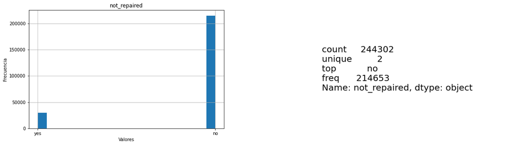

Datos ausentes: 46873

```python
histo_des(data['not_repaired'])
```

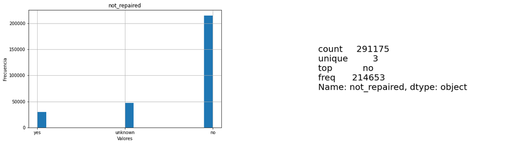

Datos ausentes: 0

```python
data['not_repaired'] = data['not_repaired'].fillna('unknown')
#Transformamos a variable categorica
data['not_repaired'] = data['not_repaired'].astype('category')
#Revisamos que el cambio se haya efectuado
histo_des(data['not_repaired'])
```

#### Columna `date_created`

```python
data['date_created'].describe(datetime_is_numeric=True)
```

```
count                           291175
mean     2016-03-20 19:31:52.552931840
min                2015-03-20 00:00:00
25%                2016-03-13 00:00:00
50%                2016-03-21 00:00:00
75%                2016-03-29 00:00:00
max                2016-04-07 00:00:00
Name: date_created, dtype: object
```

Las fechas se encuentran dentro de valores esperados.

#### Columna `number_of_pictures`

`number_of_pictures` es una **variable categorica**, hay solo una categoria y 0 valores ausentes. La transformaré a variable categorica.

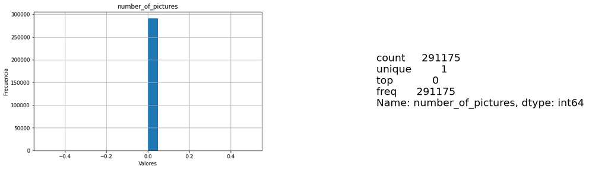

Datos ausentes: 0

```python
data['number_of_pictures'] = data['number_of_pictures'].astype('category')
histo_des(data['number_of_pictures'])
```

#### Columna `postal_code`

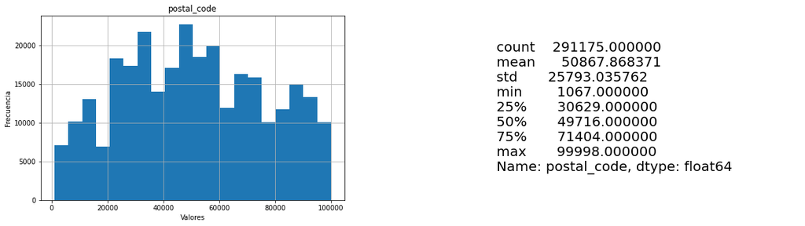

Datos ausentes: 0

```python
histo_des(data['postal_code'])
```

La variable muestra valores esperados.

#### Columna `last_seen`

```python
data['last_seen'].describe(datetime_is_numeric=True)
```

```
count                        291175
mean     2016-03-30 01:44:03.682528
min             2016-03-05 14:15:00
25%             2016-03-23 08:18:00
50%             2016-04-03 18:16:00
75%             2016-04-06 10:16:00
max             2016-04-07 14:58:00
Name: last_seen, dtype: object
```

La variable muestra fechas dentro de lo esperado.

#### Eliminamos duplicados

```python
#Evaluamos duplicados
print_mejorado(f"Duplicados: {data.duplicated().sum()}",20)
#Eliminando duplicados (si los hay)
data=data.drop_duplicates().reset_index(drop = True)
#Evaluamos duplicados
print_mejorado(f"Cantidad de duplicados luego de eliminarlos: {data.duplicated().sum()}",20)
```

Duplicados: 243

Cantidad de duplicados luego de eliminarlos: 0

### Preparacion final de la data antes del entrenamiento

Como nuestros modelos deben ser capaces de predecir el precio de un automovil en base a sus caracteristicas, vemos que hay algunas columnas que no aportan información relevante para la predicción, como es el caso de las fechas, mes de registro, código postal del usuario o número de fotografias. Por lo que procederé a eliminar estas columnas.

```python
data=data.drop(['date_crawled','registration_month','date_created','number_of_pictures','postal_code','last_seen'], axis=1)
data.info()
```

```
<class 'pandas.core.frame.DataFrame'>
RangeIndex: 290932 entries, 0 to 290931
Data columns (total 10 columns):
 #   Column             Non-Null Count   Dtype
---  ------             --------------   -----
 0   price              290932 non-null  int64
 1   vehicle_type       290932 non-null  category
 2   registration_year  290932 non-null  int64
 3   gearbox            290932 non-null  category
 4   power              290932 non-null  int64
 5   model              290932 non-null  category
 6   mileage            290932 non-null  int64
 7   fuel_type          290932 non-null  category
 8   brand              290932 non-null  category
 9   not_repaired       290932 non-null  category
dtypes: category(6), int64(4)
memory usage: 10.8 MB
```

Finalmente, tenemos nuestra data lista para entrenar con 290932 filas de información.  
Nuestra variable objetivo sera `price`.  
Respecto a las caracteristicas, vemos que tenemos 6 variables categoricas, las cuales son: `vehicle_type`,`gearbox`,`model`,`fuel_type`,`brand`y`not_repaired`.

## Entrenamiento de modelos

### Entrenamiento de modelos clásicos de regresión

En esta primera parte, entrenaré tres modelos clásicos (Arbol de decisión, Bosques Aleatorios y Regresión Lineal) y los evaluaré usando la metrica de la Raiz del error cuadrático medio (RMSE). Para cada modelo, se medirá el tiempo de entrenamiento.

```python
model_tree = DecisionTreeRegressor()
model_forest = RandomForestRegressor()
model_linear = LinearRegression()
```

Para esto, convertiré la data de entrenamiento usando la codificación One-Shot para un mejor manejo de nuestras variables categoricas.

```python
data_ohe=pd.get_dummies(data, drop_first=True,dummy_na=True)
data_ohe.head()
```

|  | price | registration_year | power | mileage | vehicle_type_convertible | vehicle_type_coupe | vehicle_type_other | vehicle_type_sedan | vehicle_type_small | vehicle_type_suv | vehicle_type_wagon | vehicle_type_nan | gearbox_manual | gearbox_unknown | gearbox_nan | model_145 | model_147 | model_156 | model_159 | model_1_reihe | model_1er | model_200 | model_2_reihe | model_300c | model_3_reihe | model_3er | model_4_reihe | model_500 | model_5_reihe | … |
| --- | --- | --- | --- | --- | --- | --- | --- | --- | --- | --- | --- | --- | --- | --- | --- | --- | --- | --- | --- | --- | --- | --- | --- | --- | --- | --- | --- | --- | --- | --- |
| 0 | 18300 | 2011 | 190 | 125000 | 0 | 1 | 0 | 0 | 0 | 0 | 0 | 0 | 1 | 0 | 0 | 0 | 0 | 0 | 0 | 0 | 0 | 0 | 0 | 0 | 0 | 0 | 0 | 0 | 0 | … |
| 1 | 9800 | 2004 | 163 | 125000 | 0 | 0 | 0 | 0 | 0 | 1 | 0 | 0 | 0 | 0 | 0 | 0 | 0 | 0 | 0 | 0 | 0 | 0 | 0 | 0 | 0 | 0 | 0 | 0 | 0 | … |
| 2 | 1500 | 2001 | 75 | 150000 | 0 | 0 | 0 | 0 | 1 | 0 | 0 | 0 | 1 | 0 | 0 | 0 | 0 | 0 | 0 | 0 | 0 | 0 | 0 | 0 | 0 | 0 | 0 | 0 | 0 | … |
| 3 | 3600 | 2008 | 69 | 90000 | 0 | 0 | 0 | 0 | 1 | 0 | 0 | 0 | 1 | 0 | 0 | 0 | 0 | 0 | 0 | 0 | 0 | 0 | 0 | 0 | 0 | 0 | 0 | 0 | 0 | … |
| 4 | 650 | 1995 | 102 | 150000 | 0 | 0 | 0 | 1 | 0 | 0 | 0 | 0 | 1 | 0 | 0 | 0 | 0 | 0 | 0 | 0 | 0 | 0 | 0 | 0 | 0 | 1 | 0 | 0 | 0 | … |

```python
data_ohe.shape
```

```
(290932, 310)
```

Con esto, vemos que nuestros DataFrame paso de tener 10 columnas, a 310 columnas (1 por cada tipo de vehiculo, modelo, marca, etc)

Como utilizaré **GridSearchCV** para encontrar los mejores hiperparametros de cada modelo, no es necesario separar la data entre data de entrenamiento y data de validación (ya que este metodo lo hace de forma interna). Por lo tanto, solo es necesario separar entre la variable objetivo (target) y las caracteristicas (features). Ademas, como ya se dijo anteriormente, optimizaré el RMSE, por lo que el atributo scoring sera `neg_root_mean_squared_error` (RMSE negativo). Por último, para los tres modelos usaré un valores de validacion cruzada (cv) de 3.

```python
#Definimos caracteristicas y objetivos
features = data_ohe.drop(['price'], axis=1)
target = data_ohe['price']
```

#### Modelo de arbol de decisión

```python
start_time = time.time()

#Hiperparametros a probar
param_grid_tree = {'max_depth': [1, 5, 10, 15]}
#Buscamos los mejores hiperparametros para DecisionTreeRegressor con 3 grupos de validacion (cv=3)
grid_search = GridSearchCV(model_tree, param_grid_tree,scoring='neg_root_mean_squared_error', cv=3)
grid_search.fit(features, target)
best_params_tree = grid_search.best_params_
best_score_tree = grid_search.best_score_

end_time = time.time()
execution_time_tree = end_time - start_time

print_mejorado(f"Mejores hiperparámetros(tree): {best_params_tree}",20)
print_mejorado(f"Mejor puntuación RMSE(tree): {abs(best_score_tree):.3f}", 20)
print_mejorado(f"Tiempo de ejecución(tree): {execution_time_tree:.1f} segundos", 20)
```

Mejores hiperparámetros(tree): {'max_depth': 15}

Mejor puntuación RMSE(tree): 1799.871

Tiempo de ejecución(tree): 47.6 segundos

#### Modelo de bosques aleatorios

```python
start_time = time.time()

#Hiperparametros a probar
param_grid_forest = {'n_estimators': [5, 10], 'max_depth': [5, 10]}

#Buscamos los mejores hiperparametros para RandomForestRegressor con 3 grupos de validacion (cv=3)
grid_search = GridSearchCV(model_forest, param_grid_forest,scoring='neg_root_mean_squared_error', cv=3)
grid_search.fit(features, target)
best_params_forest = grid_search.best_params_
best_score_forest = grid_search.best_score_

end_time = time.time()
execution_time_forest = end_time - start_time

print_mejorado(f"Mejores hiperparámetros(forest): {best_params_forest}",20)
print_mejorado(f"Mejor puntuación RMSE(forest): {abs(best_score_forest):.3f}", 20)
print_mejorado(f"Tiempo de ejecución(forest): {execution_time_forest:.1f} segundos", 20)
```

Mejores hiperparámetros(forest): {'max_depth': 10, 'n_estimators': 10}

Mejor puntuación RMSE(forest): 1836.196

Tiempo de ejecución(forest): 218.3 segundos

#### Modelo de regresión lineal

```python
start_time = time.time()

#Hiperparametros a probar
param_grid_linear = {'fit_intercept': [True, False], 'normalize': [True, False]}

#Buscamos los mejores hiperparametros para LinearRegression con 3 grupos de validacion (cv=3)
grid_search = GridSearchCV(model_linear, param_grid_linear,scoring='neg_root_mean_squared_error', cv=3)
grid_search.fit(features, target)
best_params_linear = grid_search.best_params_
best_score_linear = grid_search.best_score_

end_time = time.time()
execution_time_lineal = end_time - start_time

print_mejorado(f"Mejores hiperparámetros(linear): {best_params_linear}",20)
print_mejorado(f"Mejor puntuación RMSE(linear): {abs(best_score_linear):.3f}", 20)
print_mejorado(f"Tiempo de ejecución(linear): {execution_time_lineal:.1f} segundos", 20)
```

Mejores hiperparámetros(linear): {'fit_intercept': True, 'normalize': False}

Mejor puntuación RMSE(linear): 2493.842

Tiempo de ejecución(linear): 210.8 segundos

### Entrenamiento de modelos de potenciación del gradiente

A continuación entrenaré 3 modelos de potenciación del gradiente (CatBoost,LightGBM yXGBoost). Para todos los casos usaré **GridSearchCV** para encontrar los mejores hiperparametros y evaluaré los tiempos de entrenamiento para cada uno. Al igual que en el punto anterior como utilizaré **GridSearchCV** no es necesario separar la data entre data de entrenamiento y data de validación, ademas usaré un valor de validacion cruzada (cv) de 3.

#### Modelo de regresión CatBoost (CatBoostRegressor)

Para este modelo no es necesario que la data de entrenamiento este codificada con "One-Shoot", sin embargo, es necesario especificar cuales son las columnas categoricas, por lo que crearé una lista con los nombres de estas columnas y se las pasaré como parametro a nuestro modelo. Ademas, optimizaré el RMSE, por lo que el atributo scoring sera `neg_root_mean_squared_error` (RMSE negativo). Finalmente, probaré 5 hiperparametros diferentes, en este caso **learning_rate**, todos con una cantidad de interaciones fija de 200.

```python
#Definimos caracteristicas y objetivos
features = data.drop(['price'], axis=1)
target = data['price']
```

```python
start_time = time.time()

categoric_features = ['vehicle_type','gearbox','model','fuel_type','brand','not_repaired']

model_cat = CatBoostRegressor(loss_function="RMSE", iterations=200, random_seed=12345)

param_grid_cat = {'learning_rate': [0.3, 0.4, 0.5, 0.6, 0.7]}

#Buscamos los mejores hiperparametros para CatBoostRegressor con 3 grupos de validacion (cv=3)
grid_search = GridSearchCV(model_cat, param_grid_cat,scoring='neg_root_mean_squared_error', cv=3,verbose=2)

grid_search.fit(features, target, cat_features=categoric_features,verbose=50)
best_params_cat = grid_search.best_params_
best_score_cat = grid_search.best_score_

end_time = time.time()
execution_time_cat = end_time - start_time

print_mejorado(f"Mejores hiperparámetros(Cat): {best_params_cat}",20)
print_mejorado(f"Mejor puntuación RMSE(Cat): {abs(best_score_cat):.3f}", 20)
print_mejorado(f"Tiempo de ejecución(Cat): {execution_time_cat:.1f} segundos", 20)
```

```
Fitting 3 folds for each of 5 candidates, totalling 15 fits
0:	learn: 3454.6812123	total: 542ms	remaining: 1m 47s
50:	learn: 1650.5460500	total: 19.9s	remaining: 58.2s
100:	learn: 1590.0606906	total: 38.8s	remaining: 38s
150:	learn: 1557.9690572	total: 58.4s	remaining: 19s
199:	learn: 1533.6118925	total: 1m 17s	remaining: 0us
[CV] END ..................................learning_rate=0.3; total time= 1.3min
0:	learn: 3462.4212657	total: 480ms	remaining: 1m 35s
50:	learn: 1649.2755916	total: 19.5s	remaining: 56.9s
100:	learn: 1589.9868330	total: 38.7s	remaining: 37.9s
150:	learn: 1557.2626734	total: 57.6s	remaining: 18.7s
199:	learn: 1533.5429007	total: 1m 16s	remaining: 0us
[CV] END ..................................learning_rate=0.3; total time= 1.3min
0:	learn: 3469.1450910	total: 480ms	remaining: 1m 35s
50:	learn: 1658.3676759	total: 20s	remaining: 58.5s
100:	learn: 1596.9615338	total: 38.9s	remaining: 38.1s
150:	learn: 1563.7719963	total: 59.1s	remaining: 19.2s
199:	learn: 1542.4209941	total: 1m 19s	remaining: 0us
[CV] END ..................................learning_rate=0.3; total time= 1.3min
0:	learn: 3222.7182446	total: 481ms	remaining: 1m 35s
50:	learn: 1636.7251706	total: 19.7s	remaining: 57.6s
100:	learn: 1573.6135981	total: 40.1s	remaining: 39.3s
150:	learn: 1540.7077570	total: 59.9s	remaining: 19.5s
199:	learn: 1518.4045573	total: 1m 20s	remaining: 0us
[CV] END ..................................learning_rate=0.4; total time= 1.4min
0:	learn: 3233.0406945	total: 486ms	remaining: 1m 36s
50:	learn: 1623.1031030	total: 20.3s	remaining: 59.2s
100:	learn: 1567.5469792	total: 39.1s	remaining: 38.3s
150:	learn: 1534.1765979	total: 58.4s	remaining: 18.9s
199:	learn: 1510.8756445	total: 1m 17s	remaining: 0us
[CV] END ..................................learning_rate=0.4; total time= 1.3min
0:	learn: 3238.2888973	total: 523ms	remaining: 1m 44s
50:	learn: 1640.8009450	total: 20.7s	remaining: 1m
100:	learn: 1583.4917450	total: 40.6s	remaining: 39.8s
150:	learn: 1553.6262307	total: 1m 1s	remaining: 19.8s
199:	learn: 1528.5395371	total: 1m 20s	remaining: 0us
[CV] END ..................................learning_rate=0.4; total time= 1.4min
0:	learn: 3012.4536533	total: 485ms	remaining: 1m 36s
50:	learn: 1633.0633586	total: 19.8s	remaining: 57.8s
100:	learn: 1568.7744194	total: 39.9s	remaining: 39.1s
```

[output cut: 41 more lines]

```
100:	learn: 1550.5715862	total: 39.6s	remaining: 38.8s
150:	learn: 1514.1563499	total: 59.3s	remaining: 19.2s
199:	learn: 1488.3158574	total: 1m 18s	remaining: 0us
[CV] END ..................................learning_rate=0.7; total time= 1.3min
0:	learn: 2696.1846597	total: 486ms	remaining: 1m 36s
50:	learn: 1626.7976673	total: 19.9s	remaining: 58.1s
100:	learn: 1560.3809843	total: 39.4s	remaining: 38.6s
150:	learn: 1525.4304649	total: 58.8s	remaining: 19.1s
199:	learn: 1502.3106912	total: 1m 17s	remaining: 0us
[CV] END ..................................learning_rate=0.7; total time= 1.3min
0:	learn: 3019.1037414	total: 666ms	remaining: 2m 12s
50:	learn: 1625.3275275	total: 30.7s	remaining: 1m 29s
100:	learn: 1569.6007892	total: 1m	remaining: 59.3s
150:	learn: 1540.2650391	total: 1m 30s	remaining: 29.5s
199:	learn: 1518.4131550	total: 2m	remaining: 0us
```

Mejores hiperparámetros(Cat): {'learning_rate': 0.5}

Mejor puntuación RMSE(Cat): 1577.177

Tiempo de ejecución(Cat): 1318.9 segundos

#### Modelo de regresión LightGBM (LGBMRegressor)

```python
#Definimos caracteristicas y objetivos
features = data.drop(['price'], axis=1)
target = data['price']
```

```python
start_time = time.time()

model_lgb = lgb.LGBMRegressor(boosting_type='gbdt', objective='regression', num_leaves=31)
param_grid_lgb = {'n_estimators': [100, 200], 'learning_rate': [0.25, 0.5]}

#Buscamos los mejores hiperparametros para LGBMRegressor con 3 grupos de validacion (cv=3)
grid_search = GridSearchCV(model_lgb, param_grid_lgb,scoring='neg_root_mean_squared_error', cv=3,verbose=2)

grid_search.fit(features, target)
best_params_lgb = grid_search.best_params_
best_score_lgb = grid_search.best_score_

end_time = time.time()
execution_time_lgb = end_time - start_time

print_mejorado(f"Mejores hiperparámetros(LGB): {best_params_lgb}",20)
print_mejorado(f"Mejor puntuación RMSE(LGB): {abs(best_score_lgb):.3f}", 20)
print_mejorado(f"Tiempo de ejecución(LGB): {execution_time_lgb:.1f} segundos", 20)
```

```
Fitting 3 folds for each of 4 candidates, totalling 12 fits
[CV] END ...............learning_rate=0.25, n_estimators=100; total time=   3.8s
[CV] END ...............learning_rate=0.25, n_estimators=100; total time=   3.6s
[CV] END ...............learning_rate=0.25, n_estimators=100; total time=   4.7s
[CV] END ...............learning_rate=0.25, n_estimators=200; total time=   6.3s
[CV] END ...............learning_rate=0.25, n_estimators=200; total time=   6.1s
[CV] END ...............learning_rate=0.25, n_estimators=200; total time=   5.9s
[CV] END ................learning_rate=0.5, n_estimators=100; total time=   3.6s
[CV] END ................learning_rate=0.5, n_estimators=100; total time=   3.1s
[CV] END ................learning_rate=0.5, n_estimators=100; total time=   3.5s
[CV] END ................learning_rate=0.5, n_estimators=200; total time=   5.5s
[CV] END ................learning_rate=0.5, n_estimators=200; total time=   5.6s
[CV] END ................learning_rate=0.5, n_estimators=200; total time=   6.1s
```

Mejores hiperparámetros(LGB): {'learning_rate': 0.25, 'n_estimators': 200}

Mejor puntuación RMSE(LGB): 1527.426

Tiempo de ejecución(LGB): 64.6 segundos

#### Modelo de regresión XGBoost (XGBRFRegressor)

Para este modelo es necesario que la data de entrenamiento este codificada con "One-Shoot". Ademas, optimizaré el RMSE, por lo que el atributo scoring sera `neg_root_mean_squared_error` (RMSE negativo). Finalmente, probaré 2 hiperparametros diferentes, en este caso **learning_rate**(0.25,0.5).

```python
#Definimos caracteristicas y objetivos
features = data_ohe.drop(['price'], axis=1)
target = data_ohe['price']
```

```python
start_time = time.time()

model_xgb =xgb.XGBRFRegressor(eval_metric=mean_squared_error)

param_grid_xgb = {'learning_rate': [0.25, 0.5]}

#Buscamos los mejores hiperparametros para XGBRFRegressor con 3 grupos de validacion (cv=3)
grid_search = GridSearchCV(model_xgb, param_grid_xgb,scoring='neg_root_mean_squared_error', cv=3,verbose=2)

grid_search.fit(features, target)
best_params_xgb = grid_search.best_params_
best_score_xgb = grid_search.best_score_

end_time = time.time()
execution_time_xgb = end_time - start_time

print_mejorado(f"Mejores hiperparámetros(XGB): {best_params_xgb}",20)
print_mejorado(f"Mejor puntuación RMSE(XGB): {abs(best_score_xgb):.3f}", 20)
print_mejorado(f"Tiempo de ejecución(XGB): {execution_time_xgb:.1f} segundos", 20)
```

```
Fitting 3 folds for each of 2 candidates, totalling 6 fits
[CV] END .................................learning_rate=0.25; total time= 5.2min
[CV] END .................................learning_rate=0.25; total time= 5.2min
[CV] END .................................learning_rate=0.25; total time= 5.1min
[CV] END ..................................learning_rate=0.5; total time= 5.0min
[CV] END ..................................learning_rate=0.5; total time= 5.0min
[CV] END ..................................learning_rate=0.5; total time= 5.1min
```

Mejores hiperparámetros(XGB): {'learning_rate': 0.5}

Mejor puntuación RMSE(XGB): 3556.234

Tiempo de ejecución(XGB): 2302.2 segundos

## Análisis y comparación de los modelos

Una vez obtenidos los mejores hiperparametros para cada modelo, tanto clasicos como de potenciación del gradiente. Procederé a realizar una analisis de desempeño, tiempo de entrenamiento y tiempo de predicción para cada uno de ellos.

### Modelos clásicos de regresión

Recordamos los mejor hiperparametros obtenidos para cada modelo.

```python
print_mejorado(f"Hiperparametros tree: {best_params_tree}",20)
print_mejorado(f"Hiperparametros tree: {best_params_forest}",20)
print_mejorado(f"Hiperparametros tree: {best_params_linear}",20)
```

Hiperparametros tree: {'max_depth': 15}

Hiperparametros tree: {'max_depth': 10, 'n_estimators': 10}

Hiperparametros tree: {'fit_intercept': True, 'normalize': False}

Inicializamos los modelos con sus mejores hiperparametros.

```python
model_tree = DecisionTreeRegressor(max_depth=15)
model_forest = RandomForestRegressor(max_depth=10,n_estimators=10)
model_linear = LinearRegression(fit_intercept=True, normalize=False)
```

#### Modelo de arbol de decisión

```python
features_train, features_valid, target_train, target_valid = train_test_split(
    data_ohe.drop('price', axis=1), data_ohe['price'], test_size=0.25, random_state=12345
)

start_time = time.time()
model_tree.fit(features_train,target_train)
end_time = time.time()
train_time_tree = end_time - start_time

start_time = time.time()
predict_valid=model_tree.predict(features_valid)
end_time = time.time()
predict_time_tree = end_time - start_time

rmse_tree =mean_squared_error(target_valid,predict_valid,squared=False)

print_mejorado(f"Modelo Arbol de Decisión",30)
print_mejorado(f"Tiempo de entrenamiento: {train_time_tree:.1f}",20)
print_mejorado(f"Tiempo de predicción: {predict_time_tree:.1f}",20)
print_mejorado(f"Desempeño (RMSE): {rmse_tree:.1f}",20)
```

Modelo Arbol de Decisión

Tiempo de entrenamiento: 5.7

Tiempo de predicción: 0.1

Desempeño (RMSE): 1787.7

#### Modelo de bosques aleatorios

```python
features_train, features_valid, target_train, target_valid = train_test_split(
    data_ohe.drop('price', axis=1), data_ohe['price'], test_size=0.25, random_state=12345
)

start_time = time.time()
model_forest.fit(features_train,target_train)
end_time = time.time()
train_time_forest = end_time - start_time


start_time = time.time()
predict_valid=model_forest.predict(features_valid)
end_time = time.time()
predict_time_forest = end_time - start_time

rmse_forest =mean_squared_error(target_valid,predict_valid,squared=False)

print_mejorado(f"Modelo Bosque Aleatorio",30)
print_mejorado(f"Tiempo de entrenamiento: {train_time_forest:.1f}",20)
print_mejorado(f"Tiempo de predicción: {predict_time_forest:.1f}",20)
print_mejorado(f"Desempeño (RMSE): {rmse_forest:.1f}",20)
```

Modelo Bosque Aleatorio

Tiempo de entrenamiento: 27.7

Tiempo de predicción: 0.2

Desempeño (RMSE): 1830.9

#### Modelo de regresión lineal

```python
features_train, features_valid, target_train, target_valid = train_test_split(
    data_ohe.drop('price', axis=1), data_ohe['price'], test_size=0.25, random_state=12345
)

start_time = time.time()
model_linear.fit(features_train,target_train)
end_time = time.time()
train_time_linear = end_time - start_time


start_time = time.time()
predict_valid=model_linear.predict(features_valid)
end_time = time.time()
predict_time_linear = end_time - start_time

rmse_linear =mean_squared_error(target_valid,predict_valid,squared=False)

print_mejorado(f"Modelo Regresión Lineal",30)
print_mejorado(f"Tiempo de entrenamiento: {train_time_linear:.1f}",20)
print_mejorado(f"Tiempo de predicción: {predict_time_linear:.1f}",20)
print_mejorado(f"Desempeño (RMSE): {rmse_linear:.1f}",20)
```

Modelo Regresión Lineal

Tiempo de entrenamiento: 17.4

Tiempo de predicción: 0.2

Desempeño (RMSE): 2498.7

### Modelos de potenciación del grandiente

Recordamos los mejor hiperparametros obtenidos para cada modelo.

```python
print_mejorado(f"Hiperparametros CatBoost: {best_params_cat}",20)
print_mejorado(f"Hiperparametros LightGBM: {best_params_lgb}",20)
print_mejorado(f"Hiperparametros XGBoost: {best_params_xgb}",20)
```

Hiperparametros CatBoost: {'learning_rate': 0.5}

Hiperparametros LightGBM: {'learning_rate': 0.25, 'n_estimators': 200}

Hiperparametros XGBoost: {'learning_rate': 0.5}

Inicializamos los modelos con sus mejores hiperparametros.

```python
model_cat = CatBoostRegressor(loss_function="RMSE", iterations=200, random_seed=12345, learning_rate=0.5)
model_lgb = lgb.LGBMRegressor(boosting_type='gbdt', objective='regression', num_leaves=31,learning_rate= 0.25, n_estimators=200)
model_xgb = xgb.XGBRFRegressor(learning_rate=0.5, eval_metric=mean_squared_error)
```

#### Modelo CatBoost

```python
features_train, features_valid, target_train, target_valid = train_test_split(
    data.drop('price', axis=1), data['price'], test_size=0.25, random_state=12345
)

categoric_features = ['vehicle_type','gearbox','model','fuel_type','brand','not_repaired']

start_time = time.time()
model_cat.fit(features_train,target_train,cat_features=categoric_features,verbose=50)
end_time = time.time()
train_time_cat = end_time - start_time

start_time = time.time()
predict_valid=model_cat.predict(features_valid)
end_time = time.time()
predict_time_cat = end_time - start_time

rmse_cat =mean_squared_error(target_valid,predict_valid,squared=False)

print_mejorado(f"Modelo CatBoost",30)
print_mejorado(f"Tiempo de entrenamiento: {train_time_cat:.1f}",20)
print_mejorado(f"Tiempo de predicción: {predict_time_cat:.1f}",20)
print_mejorado(f"Desempeño (RMSE): {rmse_cat:.1f}",20)
```

```
0:	learn: 3025.2404972	total: 554ms	remaining: 1m 50s
50:	learn: 1625.7912855	total: 23.2s	remaining: 1m 7s
100:	learn: 1570.1383419	total: 45.6s	remaining: 44.7s
150:	learn: 1536.9881501	total: 1m 7s	remaining: 22s
199:	learn: 1511.6332746	total: 1m 29s	remaining: 0us
```

Modelo CatBoost

Tiempo de entrenamiento: 90.4

Tiempo de predicción: 0.3

Desempeño (RMSE): 1570.6

#### Modelo LightGBM

```python
features_train, features_valid, target_train, target_valid = train_test_split(
    data.drop('price', axis=1), data['price'], test_size=0.25, random_state=12345
)

start_time = time.time()
model_lgb.fit(features_train,target_train)
end_time = time.time()
train_time_lgb = end_time - start_time


start_time = time.time()
predict_valid=model_lgb.predict(features_valid)
end_time = time.time()
predict_time_lgb = end_time - start_time

rmse_lgb =mean_squared_error(target_valid,predict_valid,squared=False)

print_mejorado(f"Modelo LightGBM",30)
print_mejorado(f"Tiempo de entrenamiento: {train_time_lgb:.1f}",20)
print_mejorado(f"Tiempo de predicción: {predict_time_lgb:.1f}",20)
print_mejorado(f"Desempeño (RMSE): {rmse_lgb:.1f}",20)
```

Modelo LightGBM

Tiempo de entrenamiento: 5.3

Tiempo de predicción: 1.1

Desempeño (RMSE): 1521.0

#### Modelo XGBoost

```python
features_train, features_valid, target_train, target_valid = train_test_split(
    data_ohe.drop('price', axis=1), data_ohe['price'], test_size=0.25, random_state=12345
)

start_time = time.time()
model_xgb.fit(features_train,target_train)
end_time = time.time()
train_time_xgb = end_time - start_time


start_time = time.time()
predict_valid=model_xgb.predict(features_valid)
end_time = time.time()
predict_time_xgb = end_time - start_time

rmse_xgb =mean_squared_error(target_valid,predict_valid,squared=False)

print_mejorado(f"Modelo XGBoost",30)
print_mejorado(f"Tiempo de entrenamiento: {train_time_xgb:.1f}",20)
print_mejorado(f"Tiempo de predicción: {predict_time_xgb:.1f}",20)
print_mejorado(f"Desempeño (RMSE): {rmse_xgb:.1f}",20)
```

Modelo XGBoost

Tiempo de entrenamiento: 339.1

Tiempo de predicción: 1.2

Desempeño (RMSE): 3560.3

### Comparación final de todos los modelos

```python
resumen = {
    'Modelo': ['Arbol de decisión', 'Bosque Aleatorio', 'Regresión Lineal', 'CatBoost','LightGBM','XGBoost'],
    'Tiempo de entrenamiento': [train_time_tree,train_time_forest,train_time_linear,train_time_cat,train_time_lgb,train_time_xgb],
    'Tiempo de predicción': [predict_time_tree,predict_time_forest,predict_time_linear,predict_time_cat,predict_time_lgb,predict_time_xgb],
    'Desempeño (RMSE)':[rmse_tree,rmse_forest,rmse_linear,rmse_cat,rmse_lgb,rmse_xgb]
}
#Utilizo round para aproximar a un solo digito
resumen = pd.DataFrame(resumen).round(1)
resumen
```

|  | Modelo | Tiempo de entrenamiento | Tiempo de predicción | Desempeño (RMSE) |
| --- | --- | --- | --- | --- |
| 0 | Arbol de decisión | 5.7 | 0.1 | 1787.7 |
| 1 | Bosque Aleatorio | 27.7 | 0.2 | 1830.9 |
| 2 | Regresión Lineal | 17.4 | 0.2 | 2498.7 |
| 3 | CatBoost | 90.4 | 0.3 | 1570.6 |
| 4 | LightGBM | 5.3 | 1.1 | 1521.0 |
| 5 | XGBoost | 339.1 | 1.2 | 3560.3 |

## Conclusión

En base a la tabla del punto anterior podemos ver que, en general, los modelos clásicos de regresión (Arbol de decisión, Bosque Aleatorio y regresión lineal) tiene un desempeño menor que los modelos CatBoost y LightGBM, en particular el modelo de regresión lineal. Por otro lado, los modelos de potenciación del gradiente CatBoost y LightGBM mostraron un desempeño superior e incluso en el caso de LightGBM, un tiempo de entrenamiento bastante bajo, mientras que XGBoost en general de todos los modelos fue el que mostro el peor desempeño y necesito un tiempo de entrenamiento elevado. Con respecto a los tiempo de predicción, los 6 modelos predicen bastante rápido y este valor tiende a ser despreciable si lo comparamos con los tiempos de entrenamiento.

# Enlaces de interes

https://www.themachinelearners.com/xgboost-python/

https://xgboost.readthedocs.io/en/latest/python/python_api.html#xgboost.XGBRFRegressor

https://lightgbm.readthedocs.io/en/stable/Python-Intro.html

https://catboost.ai/en/docs/concepts/python-reference_catboostregressor